# modeling stroop effects (RTs) with RSA coding schemes

michael freund

2020-02-19

## about

The goal is to estimate which of a set of regressors best predicts individual differences in Stroop effect (RTs). The regressors are fits from three RSA coding schemes: a *target*, *distractor*, and *incongruency* model. Each RSA coding scheme was obtained from evoked activity within a “super-parcel”. Thus, the initial set of regressors contains $N_{\text{superparcel}} * N_{\text{coding scheme}}$ regressors.

## feature selection

- compute bivariate correlations between each regressor and Stroop effect
  - use both spearman and pearson
  - check for multivariate outliers via stahel-donoho projection techique (from WRS2 package, code lifted from [here](https://github.com/cran/WRS2/blob/master/R/outpro.R)
  - select regressors that have $R^2$ in top 20 within both pearson’s and spearman’s
    - <= 20 regressors will keep the model comparison procedure (below) tractable

```r
## (1) bivariate correlations ----

d <- stats.subjs.tdic %>% filter(roi.set %in% c("anatfunc", "md") | superparcel %in% c("vwfa", "smmouth"))

d %<>%
  group_by(superparcel, param) %>%
  mutate(
    n = seq_len(n()),
    is.out.line = n %in% outpro(partr, stroop)$out.id,
    is.out.rank = n %in% outpro(rank(partr), rank(stroop))$out.id
  )

topcors <- d %>%
  group_by(superparcel, param) %>%
  summarize(
    r.line = cor(beta, stroop),
    r.rank = cor(beta, stroop, method = "spearman"),
    r2.line = r.line^2,
    r2.rank = r.rank^2,
    r.line.nout = sum(is.out.line),
    r.rank.nout = sum(is.out.rank)
  ) %>%
  ungroup %>%
  filter(rank(-r2.line) < 21 & rank(-r2.rank) < 21) %>%
  arrange(-r2.line) %>%
  mutate(id = interaction(superparcel, param))

kable(topcors, digits = 2)
```

| superparcel | param | r.line | r.rank | r2.line | r2.rank | r.line.nout | r.rank.nout | id |
| --- | --- | --- | --- | --- | --- | --- | --- | --- |
| lppc_R | target | -0.45 | -0.38 | 0.20 | 0.14 | 4 | 0 | lppc_R.target |
| dlpfc_L | distractor | -0.43 | -0.33 | 0.18 | 0.11 | 4 | 0 | dlpfc_L.distractor |
| dlpfc_R | target | -0.36 | -0.28 | 0.13 | 0.08 | 0 | 0 | dlpfc_R.target |
| vvis_L | incongruency | -0.34 | -0.40 | 0.11 | 0.16 | 2 | 0 | vvis_L.incongruency |
| ifc_R | target | -0.32 | -0.25 | 0.10 | 0.06 | 4 | 0 | ifc_R.target |
| core_L | distractor | -0.28 | -0.26 | 0.08 | 0.07 | 1 | 0 | core_L.distractor |
| mfc_L | incongruency | 0.28 | 0.18 | 0.08 | 0.03 | 0 | 0 | mfc_L.incongruency |
| evis | incongruency | -0.27 | -0.31 | 0.07 | 0.09 | 1 | 0 | evis.incongruency |
| dpm_L | target | -0.26 | -0.28 | 0.07 | 0.08 | 5 | 0 | dpm_L.target |
| fpc_R | target | -0.23 | -0.21 | 0.05 | 0.04 | 0 | 0 | fpc_R.target |
| smmouth | distractor | 0.23 | 0.25 | 0.05 | 0.06 | 1 | 0 | smmouth.distractor |
| ifj_R | target | -0.22 | -0.19 | 0.05 | 0.04 | 2 | 0 | ifj_R.target |
| vvis_R | incongruency | -0.22 | -0.31 | 0.05 | 0.09 | 0 | 0 | vvis_R.incongruency |
| ifc_R | distractor | -0.22 | -0.20 | 0.05 | 0.04 | 0 | 0 | ifc_R.distractor |
| ifj_R | distractor | -0.20 | -0.19 | 0.04 | 0.04 | 0 | 0 | ifj_R.distractor |
| ins_L | target | -0.19 | -0.19 | 0.04 | 0.04 | 1 | 0 | ins_L.target |

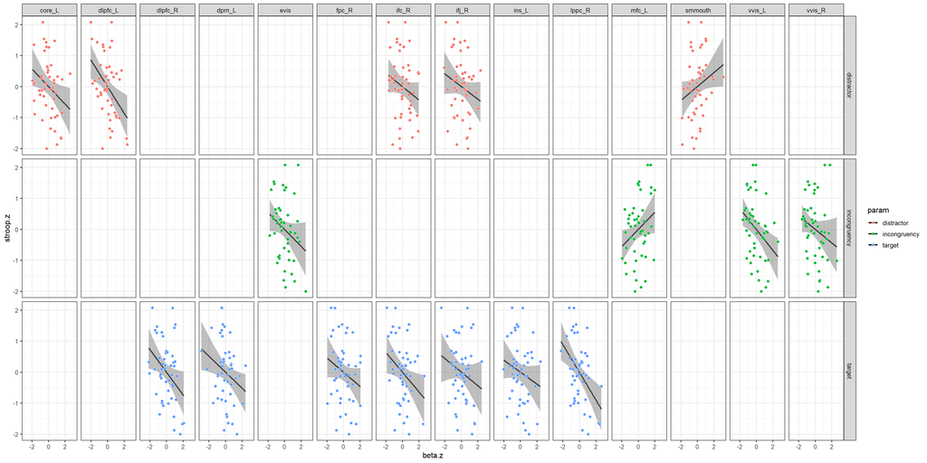

```r
## plot

d %<>%
  mutate(id = as.character(interaction(superparcel, param))) %>%
  filter(id %in% topcors$id)

d %>%
  group_by(id) %>%
  mutate(
    beta.z = scale(beta),
    stroop.z = scale(stroop),
    r = cor(beta, stroop)
  ) %>%
  ggplot(aes(beta.z, stroop.z, fill = param)) +
  facet_grid(vars(param), vars(superparcel)) +
  geom_smooth(method = "lm", se = FALSE, color = "black") +
  stat_boot_ci(n = 1E4, fill = "grey50", alpha = 0.5) +
  geom_point(shape = 21, color = "white", size = 2)
```

This narrows it down to a set of 16 regressors.

## model comparison

- multple regression via OLS
- all possible combinations of selected regressors (above) will be fit
- expected test error estimated via MSE from 10-fold cross-validation
- this procedure will be repeated 5 times and MSEs averaged across repetitions
- two types of models will be noted:
  - **minimum MSE**: the model that yields minimum MSE
  - **optimal MSE**: the model(s) with fewest parameters that yield within 1 SE of **minimum MSE** model

### code

```r
## to wide

w <- d %>%
  ungroup %>%
  select(subj, congr, stroop, beta, id) %>%
  tidyr::spread(id, beta)

## build model combinations

varnames <- as.character(unique(d$id))
nvars <- length(varnames)
combs <- lapply(1:nvars, function(x) gtools::combinations(n = nvars, r = x))  ## row indicates columns of design matrix
nmods <- sum(sapply(combs, nrow))
mse <- vector("list", nmods)
X <- as.matrix(w[varnames])
strooprt <- w$stroop
mod <- mse
k <- 10

## build cross-validation folds

set.seed(0)
folds <- lapply(
  1:5,
  function(.) createFolds(strooprt, k = k, list = TRUE, returnTrain = FALSE)
)
mse.rep.i <- matrix(NA, ncol = k, nrow = length(folds))  ## for storing MSEs hot off press

print(cbind(sapply(combs, nrow)))  ## number of models (inner loop) per combination (outer loop)
```

```
##        [,1]
##  [1,]    16
##  [2,]   120
##  [3,]   560
##  [4,]  1820
##  [5,]  4368
##  [6,]  8008
##  [7,] 11440
##  [8,] 12870
##  [9,] 11440
## [10,]  8008
## [11,]  4368
## [12,]  1820
## [13,]   560
## [14,]   120
## [15,]    16
## [16,]     1
```

```r
## estimate test error

starttime <- Sys.time()
a <- 1
for (comb.i in seq_along(combs)) {
  # comb.i = 1

  comb <- combs[[comb.i]]

  for (model.i in seq_len(nrow(comb))) {
    # model.i = 2

    ## build model

    regs.i <- comb[model.i, ]  ## indices for regressors
    Xi <- cbind(b0 = 1, X[, regs.i])
    colnames(Xi)[-1] <- varnames[regs.i]

    ## get response (folds)

    for (rep.i in seq_along(folds)) {
      # rep.i = 1

      unlist.me <- lapply(
        folds[[rep.i]],
        function(., x, y) {
          xtrn <- x[-., ]
          xtst <- x[., ]
          ytrn <- y[-.]
          ytst <- y[.]
          fit  <- .lm.fit(xtrn, ytrn)
          yhat <- xtst %*% fit$coefficients

          mean((ytst - yhat)^2)

        },
        x = Xi,
        y = strooprt
      )

      mse.rep.i[rep.i, ] <- unlist(unlist.me, use.names = FALSE)

    }

    # mse[[a]] <- colMeans(mse.rep.i)  ## average MSEs across repetitions
    mse[[a]] <- c(mse.rep.i)
    mod[[a]] <- varnames[regs.i]

    a <- a + 1

  }

  print(comb.i)

}
```

```
## [1] 1
## [1] 2
## [1] 3
## [1] 4
## [1] 5
## [1] 6
## [1] 7
## [1] 8
## [1] 9
## [1] 10
## [1] 11
## [1] 12
## [1] 13
## [1] 14
## [1] 15
## [1] 16
```

```r
(endtime <- Sys.time() - starttime)
```

```
## Time difference of 4.034 mins
```

### results

#### minimum MSE model

```r
mse.bar <- vapply(mse, mean, numeric(1))  ## MSEs per model (averaged across folds)
m.best <- which.min(mse.bar)
se.best <- sd(mse[[m.best]]) / sqrt(length(mse[[m.best]]))  ## expected SE of test error for min mse model
nparams <- vapply(mod, length, numeric(1)) + 1  ## number of params of each model
mse[m.best] %>% unlist %>% mean / k  ## MSE per fold
```

```
## [1] 62.71
```

```r
mod[m.best]  ## winning model params
```

```
## [[1]]
## [1] "smmouth.distractor" "dlpfc_L.distractor" "evis.incongruency"
## [4] "ifj_R.distractor"   "lppc_R.target"      "mfc_L.incongruency"
```

```r
range(mse.bar)
```

```
## [1]  627.1 1281.8
```

```r
# plot(nparams, mse.bar)

fit.best <- lm(scale(strooprt) ~ ., data = as.data.frame(scale(X[, mod[[m.best]]])))
summary(fit.best)
```

```
##
## Call:
## lm(formula = scale(strooprt) ~ ., data = as.data.frame(scale(X[,
##     mod[[m.best]]])))
##
## Residuals:
##     Min      1Q  Median      3Q     Max
## -1.0939 -0.5111 -0.0346  0.4055  1.6611
##
## Coefficients:
##                     Estimate Std. Error t value Pr(>|t|)
## (Intercept)        -1.62e-17   1.01e-01    0.00   1.0000
## smmouth.distractor  2.58e-01   1.10e-01    2.35   0.0236 *
## dlpfc_L.distractor -3.64e-01   1.06e-01   -3.45   0.0013 **
## evis.incongruency  -3.04e-01   1.06e-01   -2.86   0.0066 **
## ifj_R.distractor   -2.02e-01   1.09e-01   -1.85   0.0715 .
## lppc_R.target      -2.89e-01   1.07e-01   -2.70   0.0099 **
## mfc_L.incongruency  3.52e-01   1.04e-01    3.38   0.0016 **
## ---
## Signif. codes:  0 '***' 0.001 '**' 0.01 '*' 0.05 '.' 0.1 ' ' 1
##
## Residual standard error: 0.705 on 42 degrees of freedom
## Multiple R-squared:  0.565,  Adjusted R-squared:  0.502
## F-statistic: 9.08 on 6 and 42 DF,  p-value: 2.26e-06
```

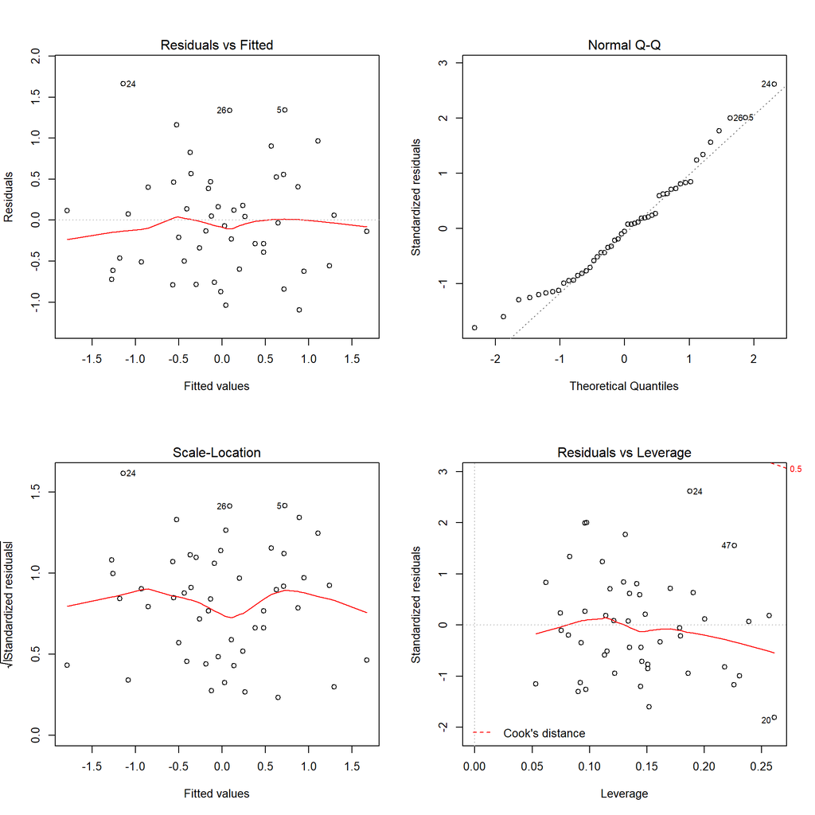

```r
par(mfrow = c(2, 2))
plot(fit.best)
```

```r
## TODO: make better plot!
```

#### optimum MSE model (using 1SE rule)

```r
thresh <- mse.bar[m.best] + se.best
is.below <- mse.bar < thresh
is.parsim <- nparams <= min(nparams[is.below])
is.viable <- is.below & is.parsim

mod[is.viable]  ## least complex mods within 1SE(MSE) of best model
```

```
## [[1]]
## [1] "dlpfc_L.distractor" "evis.incongruency"  "lppc_R.target"
## [4] "mfc_L.incongruency"
##
## [[2]]
## [1] "dlpfc_L.distractor"  "lppc_R.target"       "mfc_L.incongruency"
## [4] "vvis_L.incongruency"
```

```r
sapply(mse[is.viable], function(.) mean(unlist(.)) / k)  ## their MSEs
```

```
## [1] 66.09 64.10
```

```r
(mod.winning <- mod[is.viable][[which.min(mse.bar[is.viable])]])  ## of those, the model with lowest MSE
```

```
## [1] "dlpfc_L.distractor"  "lppc_R.target"       "mfc_L.incongruency"
## [4] "vvis_L.incongruency"
```

```r
fit.optim <- lm(scale(strooprt) ~ ., data = as.data.frame(scale(X[, mod.winning])))
summary(fit.optim)
```

```
##
## Call:
## lm(formula = scale(strooprt) ~ ., data = as.data.frame(scale(X[,
##     mod.winning])))
##
## Residuals:
##     Min      1Q  Median      3Q     Max
## -1.4723 -0.5315 -0.0121  0.4287  1.4030
##
## Coefficients:
##                      Estimate Std. Error t value Pr(>|t|)
## (Intercept)         -4.26e-17   1.04e-01    0.00   1.0000
## dlpfc_L.distractor  -3.23e-01   1.08e-01   -2.99   0.0046 **
## lppc_R.target       -3.28e-01   1.08e-01   -3.03   0.0041 **
## mfc_L.incongruency   3.66e-01   1.09e-01    3.35   0.0017 **
## vvis_L.incongruency -3.75e-01   1.10e-01   -3.41   0.0014 **
## ---
## Signif. codes:  0 '***' 0.001 '**' 0.01 '*' 0.05 '.' 0.1 ' ' 1
##
## Residual standard error: 0.729 on 44 degrees of freedom
## Multiple R-squared:  0.513,  Adjusted R-squared:  0.468
## F-statistic: 11.6 on 4 and 44 DF,  p-value: 1.66e-06
```

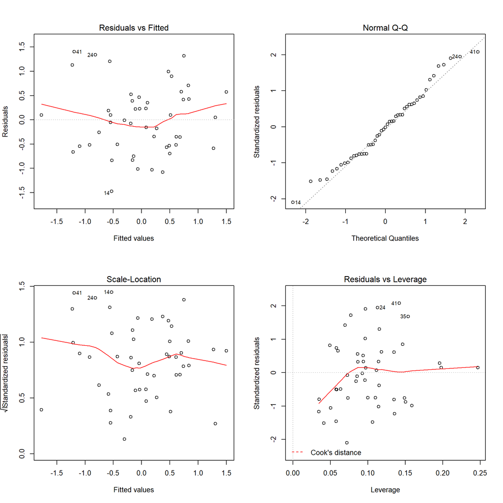

```r
par(mfrow = c(2, 2))
plot(fit.optim)
```

```r
# d <- d %>%
#   select(subj, congr, incon, superparcel, param, beta) %>%
#   as.data.table %>%
#   melt(value.name = "rt", id.vars = c("subj", "superparcel", "param", "beta"), measure.vars = c("congr", "incon"))

w.scale <- data.frame(scale(w[mod.winning]))

w.resid <- data.frame(
  dlpfc_L.distractor  = lm(lppc_R.target ~ ., w.scale)$resid,
  lppc_R.target       = lm(lppc_R.target ~ ., w.scale)$resid,
  mfc_L.incongruency  = lm(mfc_L.incongruency ~ ., w.scale)$resid,
  vvis_L.incongruency = lm(vvis_L.incongruency ~ ., w.scale)$resid
)

partials <- cbind(blups, w.resid)

cor(partials$stroop, partials$mfc_L.incongruency)
```

```
## [1] 0.3522
```

```r
cor(partials$stroop, partials$lppc_R.target)
```

```
## [1] -0.3186
```

```r
cor(partials$stroop, partials$vvis_L.incongruency)
```

```
## [1] -0.3592
```

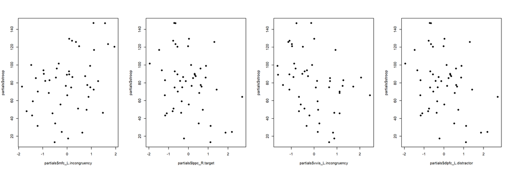

```r
par(mfrow = c(1, 4))
plot(partials$mfc_L.incongruency, partials$stroop, pch = 16)
plot(partials$lppc_R.target, partials$stroop, pch = 16)
plot(partials$vvis_L.incongruency, partials$stroop, pch = 16)
plot(partials$dlpfc_L.distractor, partials$stroop, pch = 16)
```

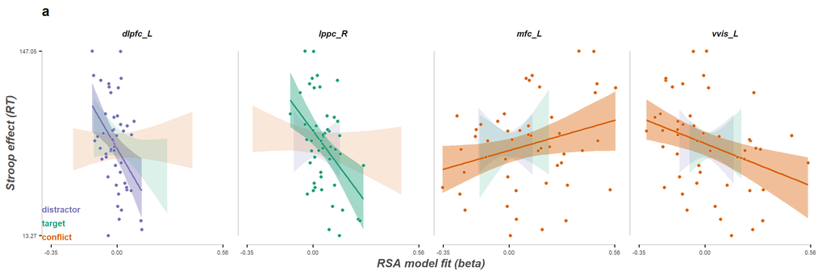

```r
d.long <- stats.subjs.tdic %>%
  filter(
    roi.set == "anatfunc", superparcel %in% c("mfc_L", "dlpfc_L", "vvis_L", "lppc_R")
    )
nsim <- 1E4
d.long %<>%
  mutate(
    is.selected.param = ifelse(
      (superparcel == "dlpfc_L" & param == "distractor") |
        (superparcel %in% c("vvis_L", "mfc_L") & param == "incongruency") |
        (superparcel == "lppc_R" & param == "target"),
      TRUE,
      FALSE
    ),
    note.incon = ifelse(superparcel == "dlpfc_L" & param == "distractor", "incongruency", ""),
    note.targt = ifelse(superparcel == "dlpfc_L" & param == "distractor", "target", ""),
    note.distr = ifelse(superparcel == "dlpfc_L" & param == "distractor", "distractor", "")
  )
note.incon <- data.frame(
  superparcel = "dlpfc_L",
  param = "distractor",
  lab = "conflict"
)
note.distr <- data.frame(
  superparcel = "dlpfc_L",
  param = "distractor",
  lab = "distractor"
)
note.targt <- data.frame(
  superparcel = "dlpfc_L",
  param = "distractor",
  lab = "target"
)

plot.range <- d.long %>%
  filter(superparcel %in% c("dlpfc_L", "vvis_L", "mfc_L", "lppc_L")) %>%
  summarize(
    max.stroop = max(stroop),
    min.stroop = min(stroop),
    min.beta = min(beta),
    max.beta = max(beta)
  )

d.long %>%
  ggplot(
    aes(beta, stroop, fill = param, color = param)
    ) +
  stat_boot_ci(aes(alpha = ifelse(is.selected.param, 0.4, 0.15)), n = nsim, color = "transparent") +
  geom_smooth(
    data = d.long %>% filter(is.selected.param),
    aes(alpha = ifelse(is.selected.param, 0.5, 0.1)),
    method = "lm", se = FALSE
    ) +
  scale_alpha_identity() +
  geom_point(data = d.long %>% filter(is.selected.param), shape = 21, color = "white", size = 2) +
  facet_grid(cols = vars(superparcel)) +
  scale_color_manual(values = c(incongruency = "#d95f02", target = "#1b9e77", distractor = "#7570b3")) +
  scale_fill_manual(values = c(incongruency = "#d95f02", target = "#1b9e77", distractor = "#7570b3")) +
  theme_minimal(base_size = 15) +
  theme(
    axis.ticks       = element_line(),
    axis.text        = element_text(size = rel(0.5), color = "grey30"),
    # axis.text.y      = element_text(color = "transparent"),
    axis.title       = element_text(color = "grey30", face = "bold.italic"),
    # axis.title.y     = element_text(color = "transparent"),
    panel.background = element_blank(),
    panel.grid       =  element_blank(),
    legend.position  = "none",
    legend.direction = "horizontal",
    legend.title     = element_blank(),
    legend.text      = element_text(color = "grey30"),
    axis.line        = element_blank(),
    strip.background = element_blank(),
    strip.text       = element_text(face = "bold.italic", size = rel(0.75)),
    title            = element_text(face = "bold")
  ) +
  scale_x_continuous(
    breaks = c(plot.range$min.beta, 0, plot.range$max.beta) %>% round(2)
  ) +
  scale_y_continuous(
    breaks = c(plot.range$min.stroop, plot.range$max.stroop) %>% round(2)
  ) +
  geom_segment(
    aes(y = plot.range$min.stroop, yend = plot.range$max.stroop, x = -Inf, xend = -Inf),
    color = "grey50", size = 0.25
    ) +
  geom_segment(
      aes(x = plot.range$min.beta, xend = plot.range$max.beta, y = -Inf, yend = -Inf),
      color = "grey50", size = 0.25
      ) +
  labs(x = "RSA model fit (beta)", y = "Stroop effect (RT)", title = "a") +
  geom_text(
    data = note.incon, aes(label = lab), color = colors.model["incongruency"], x = -Inf, y = 10,
    fontface = "bold", vjust = 0, hjust = 0
    ) +
  geom_text(
    data = note.targt, aes(label = lab), color = colors.model["target"], x = -Inf, y = 20,
    fontface = "bold", vjust = 0, hjust = 0
    ) +
  geom_text(
    data = note.distr, aes(label = lab), color = colors.model["distractor"], x = -Inf, y = 30,
    fontface = "bold", vjust = 0, hjust = 0
    )
```

## testing hypotheses in MLM

- tested via cross-level interaction between fit to coding scheme and trial type

```r
## fit MLM

fit <- readRDS(here("out", "behav", "fit1-het-trim_group201902.RDS"))
behav <- fit$data
behav %<>% full_join(cbind(subj = w$subj, w.scale), by = "subj")
fit.win <- lme(
  scale(rt) ~ trial.type + lppc_R.target + mfc_L.incongruency + vvis_L.incongruency + dlpfc_L.distractor +
    trial.type:lppc_R.target +
    trial.type:mfc_L.incongruency +
    trial.type:vvis_L.incongruency +
    trial.type:dlpfc_L.distractor,
  random  = ~ trial.type | subj,
  data    = behav,
  weights = varIdent(form = ~ 1 | subj),
  control = lmeControl(maxIter = 1e5, msMaxIter = 1e5, niterEM = 1e5, msMaxEval = 1e5),
  method  = "REML"
)

summary(fit.win)
```

```
## Linear mixed-effects model fit by REML
##  Data: behav
##     AIC   BIC logLik
##   19909 20357  -9892
##
## Random effects:
##  Formula: ~trial.type | subj
##  Structure: General positive-definite, Log-Cholesky parametrization
##                 StdDev Corr
## (Intercept)     0.6436 (Intr)
## trial.typeincon 0.1119 -0.077
## Residual        0.4570
##
## Variance function:
##  Structure: Different standard deviations per stratum
##  Formula: ~1 | subj
##  Parameter estimates:
##      107321      123117      130114      132017      138837      141422
##      1.0000      1.9620      1.3643      1.6351      1.4219      1.4881
##      150423      158136      160830      161832      165032      171330
##      1.9278      0.8948      3.9379      3.9656      2.4030      1.3614
##      178243      178950      182436      197449      203418      204319
##      2.2536      1.0434      2.5580      1.7322      1.0557      2.4013
##      300618      317332      346945      352738      448347      580650
##      0.7637      0.9245      1.2492      2.4336      1.7163      3.0225
##      594156      601127      765864      814649      843151      849971
##      0.9123      1.6975      0.8079      1.3686      1.7268      2.1465
##      873968      877168 DMCC1971064 DMCC2442951 DMCC3062542 DMCC4854075
##      1.1298      1.8907      1.1623      0.6327      1.4087      0.9752
## DMCC5009144 DMCC6418065 DMCC6484785 DMCC6661074 DMCC6671683 DMCC6721369
##      0.7304      0.7730      1.6407      1.0180      0.7512      0.7992
## DMCC7297690 DMCC7921988 DMCC8033964 DMCC8050964 DMCC9441378 DMCC9478705
##      1.1168      1.5472      0.7151      1.2237      1.9472      1.2263
## DMCC9953810
##      1.3060
## Fixed effects: scale(rt) ~ trial.type + lppc_R.target + mfc_L.incongruency +      vvis_L.incongruency + dlpfc_L.distractor + trial.type:lppc_R.target +      trial.type:mfc_L.incongruency + trial.type:vvis_L.incongruency +      trial.type:dlpfc_L.distractor
##                                       Value Std.Error    DF t-value p-value
## (Intercept)                         -0.2140   0.09273 10174  -2.308  0.0210
## trial.typeincon                      0.3367   0.02106 10174  15.982  0.0000
## lppc_R.target                        0.0189   0.09658    44   0.195  0.8461
```

[output cut: 20 more lines]

```
## lppc_R.target
## mfc_L.incongruency
## vvis_L.incongruency
## dlpfc_L.distractor
## trial.typeincon:lppc_R.target
## trial.typeincon:mfc_L.incongruency  -0.043
## trial.typeincon:vvis_L.incongruency -0.034 -0.284
## trial.typeincon:dlpfc_L.distractor  -0.175  0.008          -0.105
##
## Standardized Within-Group Residuals:
##     Min      Q1     Med      Q3     Max
## -4.8809 -0.6306 -0.1746  0.4224 10.0733
##
## Number of Observations: 10228
## Number of Groups: 49
```

```r
# intervals(fit.winning, which = "fixed")


## TODO: set up double dissociation
# fit.pfc <- lme(
#   scale(rt) ~ trial.type * scheme * region,
#   random  = ~ trial.type | subj,
#   data    = behav,
#   weights = varIdent(form = ~ 1 | subj),
#   control = lmeControl(maxIter = 1e5, msMaxIter = 1e5, niterEM = 1e5, msMaxEval = 1e5),
#   method  = "REML"
# )


# ## plot: MLM
#
# blups$incon <- blups$congr + blups$stroop
#
# blups.long <- full_join(
#   blups %>%
#     select(subj, congr, incon) %>%
#     reshape2::melt(variable.name = "trial.type", value.name = "rt"),
#   blups %>%
#     select(subj, lppc_R.target:vvis_L.incongruency) %>%
#     reshape2::melt(value.name = "beta"),
#   by = "subj"
# )
#
# blups.long %>%
#   ggplot(aes(beta, rt, color = trial.type)) +
#   facet_grid(cols = vars(variable)) +
#   geom_smooth(
#     data = blups.long %>% filter(trial.type == "congr"), method = "lm", se = FALSE
#   ) +
#   geom_smooth(
#     data = blups.long %>% filter(trial.type == "incon"), method = "lm", se = FALSE
#   ) +
#   # stat_boot_ci(
#   #   data = blups.long %>% filter(trial.type == "incon"), alpha = 0.2
#   # ) +
#   # stat_boot_ci(
#   #   data = blups.long %>% filter(trial.type == "congr"), alpha = 0.2
#   # )
#   geom_point(alpha = 0.2) +
#   scale_color_brewer(type = "qual", palette = 2)
# # geom_line(aes(group = subj), color = "grey20")
# blups %>%
#   select(-congr, -incon) %>%
#   reshape2::melt(id.var = c("subj", "stroop")) %>%
#   ggplot(aes(value, stroop, color = variable)) +
#   facet_grid(cols = vars(variable)) +
#   geom_smooth(method = "lm", se = FALSE) +
#   geom_smooth(method = "lm", se = FALSE) +
#   stat_boot_ci(alpha = 0.3) +
#   # stat_boot_ci(
#   #   data = blups.long %>% filter(trial.type == "congr"), alpha = 0.2
#   # )
#   geom_point() +
#   scale_color_brewer(type = "qual", palette = 2)
```

## MDS

### setup

```r
## setup ----

subjs <- blups$subj
n.subj <- length(subjs)
n.model <- length(mod.winning)
n.stim <- length(bias.items)

## get data

R <- readRDS(here("out", "rsa", "obsv", "rsarray_pro_bias_acc-only_masks_pearson_residual-linear.rds"))
dimnames(R)
```

```
## $.row
##  [1] "blueBLUE"     "purpleBLUE"   "redBLUE"      "whiteBLUE"    "bluePURPLE"
##  [6] "purplePURPLE" "redPURPLE"    "whitePURPLE"  "blueRED"      "purpleRED"
## [11] "redRED"       "whiteRED"     "blueWHITE"    "purpleWHITE"  "redWHITE"
## [16] "whiteWHITE"
##
## $.col
##  [1] "blueBLUE"     "purpleBLUE"   "redBLUE"      "whiteBLUE"    "bluePURPLE"
##  [6] "purplePURPLE" "redPURPLE"    "whitePURPLE"  "blueRED"      "purpleRED"
## [11] "redRED"       "whiteRED"     "blueWHITE"    "purpleWHITE"  "redWHITE"
## [16] "whiteWHITE"
##
## $subj
##  [1] "107321"      "115825"      "123117"      "130114"      "130518"
##  [6] "132017"      "138837"      "141422"      "150423"      "158136"
```

[output cut: 28 more lines]

```r
R <- R[, , subjs, c("anatfunc_lppc_R", "anatfunc_mfc_L", "anatfunc_vvis_L", "anatfunc_dlpfc_L")]
```

### average geometries of ‘winning’ regions

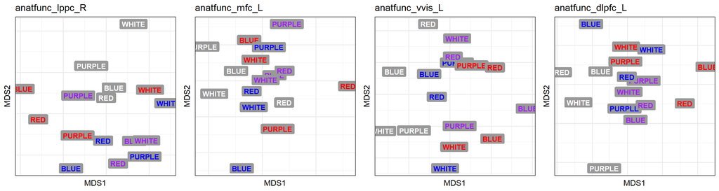

```r
## mean matrices

Rbar <- apply(R, c(1:2, 4), function(x) tanh(mean(atanh(x))))  ## cross-subject average RSM per region
Dbar <- 1 - Rbar  ## same, but correlation distance

rois <- dimnames(Dbar)$roi
Mbar <- array(
  NA,
  dim = c(stim = n.stim, dim = 2, roi = length(rois)),
  dimnames = list(stim = bias.items, dims = c("MDS1", "MDS2"), roi = rois)
  )
p.mds.ave <- vector("list", length(rois)) %>% setNames(rois)
for (roi in rois) {

  Mbar[, , roi] <- Dbar[, , roi] %>% vegan::metaMDS(k = 2, trace = FALSE) %>% .$points

  p.mds.ave[[roi]] <- Dbar[, , roi] %>%
    vegan::metaMDS(k = 2, trace = FALSE) %>%
    .$points %>%
    mds.to.df %>%
    plot.mds +
    labs(title = roi)

}
grid.arrange(p.mds.ave[[1]], p.mds.ave[[2]], p.mds.ave[[3]], p.mds.ave[[4]], ncol = 4)
```

### trichotomized by Stroop RT

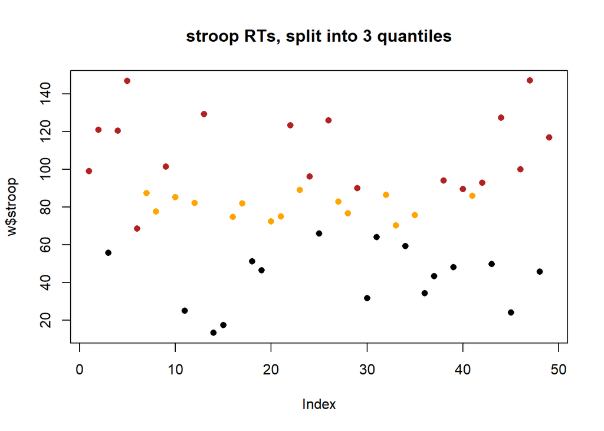

```r
topthird <- w$subj[w$stroop < quantile(w$stroop, 1/3)]
midthird <- w$subj[w$stroop < quantile(w$stroop, 2/3) & w$stroop > quantile(w$stroop, 1/3)]
botthird <- w$subj[w$stroop > quantile(w$stroop, 2/3)]

par(mfrow = c(1, 1))
plot(
  w$stroop,
  pch = 16,
  col = ifelse(w$subj %in% topthird, "black", ifelse(w$subj %in% midthird, "orange", "firebrick")),
  main = "stroop RTs, split into 3 quantiles"
)
```

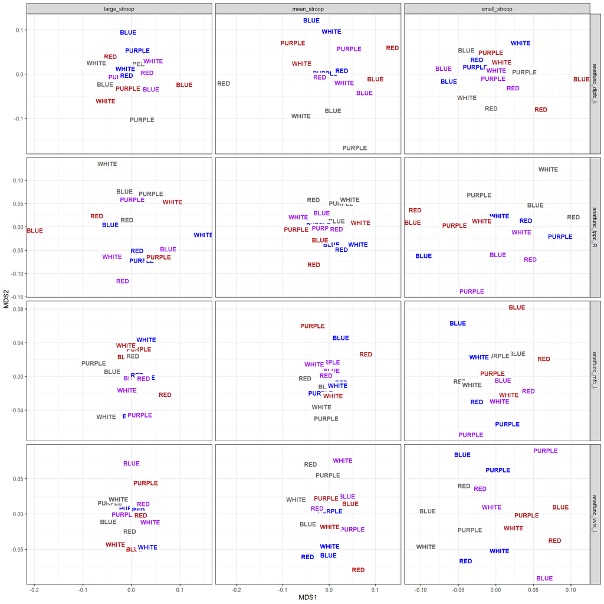

```r
Dbar.top <- 1 - R[, , topthird, ] %>% apply(c(".row", ".col", "roi"), function(x) tanh(mean(atanh(x))))
Dbar.mid <- 1 - R[, , midthird, ] %>% apply(c(".row", ".col", "roi"), function(x) tanh(mean(atanh(x))))
Dbar.bot <- 1 - R[, , botthird, ] %>% apply(c(".row", ".col", "roi"), function(x) tanh(mean(atanh(x))))

l.mrot.tri <- vector("list", length(rois))
p.mds.tri <- vector("list", length(rois)) %>% setNames(rois)
for (roi in rois) {

  Mbar.top <- metaMDS(Dbar.top[, , roi], k = 2, trace = FALSE)$points
  Mbar.mid <- metaMDS(Dbar.mid[, , roi], k = 2, trace = FALSE)$points
  Mbar.bot <- metaMDS(Dbar.bot[, , roi], k = 2, trace = FALSE)$points

  Mrot.tri <- rbind(
    procrustes(Mbar[, , roi], Mbar.top) %>% .$Yrot %>% reshape2::melt() %>% mutate(tri = "small_stroop"),
    procrustes(Mbar[, , roi], Mbar.mid) %>% .$Yrot %>% reshape2::melt() %>% mutate(tri = "mean_stroop"),
    procrustes(Mbar[, , roi], Mbar.bot) %>% .$Yrot %>% reshape2::melt() %>% mutate(tri = "large_stroop")
  )

  l.mrot.tri[[roi]] <- Mrot.tri %>%
    tidyr::spread(Var2, value) %>%
    rename(stim = Var1, MDS1 = "1", MDS2 = "2") %>%
    cbind(split.str.item(.$stim)) %>%
    mutate(roi = roi)

}

d.mrot.tri <- do.call(rbind, l.mrot.tri)

d.mrot.tri %>%
  ggplot(aes(x = MDS1, y = MDS2, fill = color)) +
  scale_fill_manual(values = c(blue = "blue", white = "grey40", red = "firebrick", purple = "purple")) +
  scale_color_manual(values = c(blue = "blue", white = "grey40", red = "firebrick", purple = "purple")) +
  geom_label(
    aes(label = word, color = color), fill = "white", fontface = "bold", label.size = 0
  ) +
  facet_grid(vars(roi), vars(tri), scales = "free") +
  theme(legend.position = "none")
```

### centroids and bootstrapped ellipses

```r
n.resamples <- 1E3
l.mrot.boot <- vector("list", length(rois)) %>% setNames(rois)
set.seed(0)
time.beg <- Sys.time()
for (roi in rois) {

  mrot.boot <- vector("list", n.resamples)
  for (sample.i in seq_len(n.resamples)) {

    ## get resamples

    topthird.i <- sample(topthird, replace = TRUE)
    midthird.i <- sample(midthird, replace = TRUE)
    botthird.i <- sample(botthird, replace = TRUE)

    ## get stats

    D.top <- 1 - apply(R[, , topthird.i, roi], 1:2, function(x) tanh(mean(atanh(x))))
    D.mid <- 1 - apply(R[, , midthird.i, roi], 1:2, function(x) tanh(mean(atanh(x))))
    D.bot <- 1 - apply(R[, , botthird.i, roi], 1:2, function(x) tanh(mean(atanh(x))))

    M.top <- metaMDS(D.top, k = 2, trace = FALSE)$points
    M.mid <- metaMDS(D.mid, k = 2, trace = FALSE)$points
    M.bot <- metaMDS(D.bot, k = 2, trace = FALSE)$points

    mrot.boot[[sample.i]] <- rbind(
      M.mid %>% procrustes(Mbar[, , roi], ., scale = TRUE) %>% .$Yrot %>%
        data.frame(tri = "mid") %>%
        rename(MDS1 = "X1", MDS2 = "X2") %>%
        tibble::rownames_to_column("stim") %>%
        bind_cols(., split.str.item(.$stim)),
      M.top %>% procrustes(Mbar[, , roi], ., scale = TRUE) %>% .$Yrot %>%
        data.frame(tri = "top") %>%
        rename(MDS1 = "X1", MDS2 = "X2") %>%
        tibble::rownames_to_column("stim") %>%
        bind_cols(., split.str.item(.$stim)),
      M.bot %>% procrustes(Mbar[, , roi], ., scale = TRUE) %>% .$Yrot %>%
        data.frame(tri = "bot") %>%
        rename(MDS1 = "X1", MDS2 = "X2") %>%
        tibble::rownames_to_column("stim") %>%
        bind_cols(., split.str.item(.$stim))
    )

    mrot.boot[[sample.i]]$iter <- sample.i

  }

  l.mrot.boot[[roi]] <- mrot.boot

  print(roi)

}
```

```
## [1] "anatfunc_lppc_R"
```

```
## [1] "anatfunc_mfc_L"
## [1] "anatfunc_vvis_L"
## [1] "anatfunc_dlpfc_L"
```

```r
(time.run <- Sys.time() - time.beg)
```

```
## Time difference of 13.38 mins
```

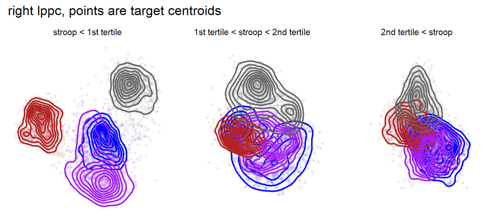

```r
## lppc

mrot.boot.lppc.l <- l.mrot.boot[[1]]
mrot.boot.lppc.l <- do.call(rbind, mrot.boot.lppc.l)

mrot.boot.lppc.l %>%
  mutate(
    color = as.character(color),
    tri = relevel(tri, "top")
  ) %>%
  group_by(iter, color, tri) %>%
  summarize(MDS1 = mean(MDS1), MDS2 = mean(MDS2)) %>%
  ggplot(aes(x = MDS1, y = MDS2, color = color)) +
  geom_point(alpha = 0.1, shape = 16) +
  geom_density_2d(size = 1) +
  scale_color_manual(values = c(blue = "blue", white = "grey40", red = "firebrick", purple = "purple")) +
  facet_grid(
    cols = vars(tri),
    labeller = labeller(
      tri = c(top = "stroop < 1st tertile", mid = "1st tertile < stroop < 2nd tertile", bot = "2nd tertile < stroop")
    )
  ) +
  theme_minimal(base_size = 14) +
  theme(
    panel.grid = element_blank(),
    axis.text =  element_blank(),
    axis.title = element_blank(),
    legend.position = "none"
  ) +
  labs(title = "right lppc, points are target centroids")
```

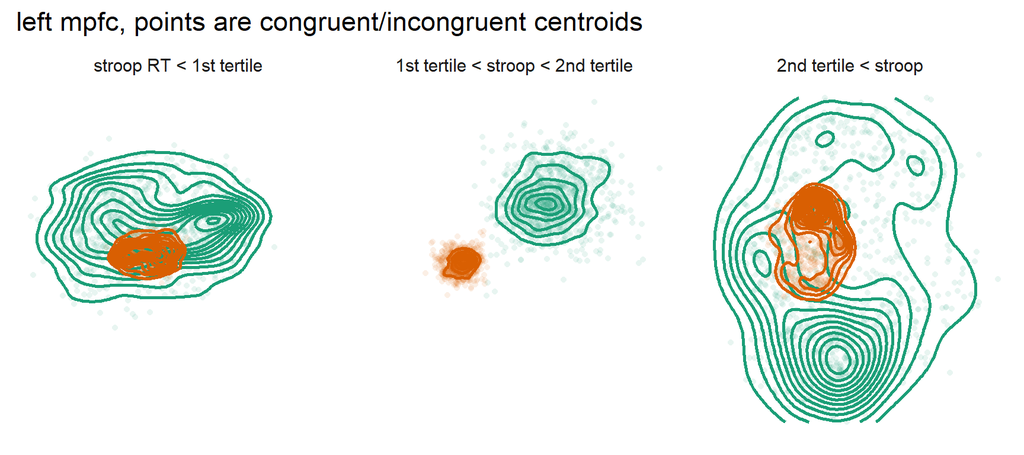

```r
## mpfc

mrot.boot.mfc.l <- l.mrot.boot[[2]]
mrot.boot.mfc.l <- do.call(rbind, mrot.boot.mfc.l)

mrot.boot.mfc.l %>%
  mutate(
    congruency = as.character(congruency),
    tri = relevel(tri, "top")
  ) %>%
  group_by(iter, congruency, tri) %>%
  summarize(MDS1 = mean(MDS1), MDS2 = mean(MDS2)) %>%
  ggplot(aes(x = MDS1, y = MDS2, color = congruency)) +
  geom_point(alpha = 0.1, aes(fill = congruency), shape = 16) +
  geom_density_2d(size = 1) +
  scale_fill_brewer(type = "qual", palette = 2) +
  scale_color_brewer(type = "qual", palette = 2) +
  facet_grid(
    cols = vars(tri),
    labeller = labeller(
      tri = c(top = "stroop RT < 1st tertile", mid = "1st tertile < stroop < 2nd tertile", bot = "2nd tertile < stroop")
    )
  ) +
  theme_minimal(base_size = 14) +
  theme(
    panel.grid = element_blank(),
    axis.text =  element_blank(),
    axis.title = element_blank(),
    legend.position = "none"
  ) +
  labs(title = "left mpfc, points are congruent/incongruent centroids")
```

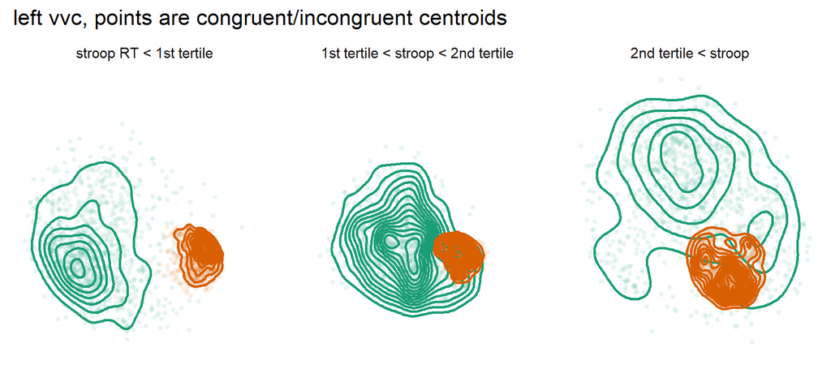

```r
## vvis

mrot.boot.vvis.l <- l.mrot.boot[[1]]
mrot.boot.vvis.l <- do.call(rbind, mrot.boot.vvis.l)

mrot.boot.vvis.l %>%
   mutate(
    congruency = as.character(congruency),
    tri = relevel(tri, "top")
  ) %>%
  group_by(iter, congruency, tri) %>%
  summarize(MDS1 = mean(MDS1), MDS2 = mean(MDS2)) %>%
  ggplot(aes(x = MDS1, y = MDS2, color = congruency)) +
  geom_point(alpha = 0.1, aes(fill = congruency), shape = 16) +
  geom_density_2d(size = 1) +
  scale_fill_brewer(type = "qual", palette = 2) +
  scale_color_brewer(type = "qual", palette = 2) +
    facet_grid(
    cols = vars(tri),
    labeller = labeller(
      tri = c(top = "stroop RT < 1st tertile", mid = "1st tertile < stroop < 2nd tertile", bot = "2nd tertile < stroop")
    )
  ) +
  theme_minimal(base_size = 14) +
  theme(
    panel.grid = element_blank(),
    axis.text =  element_blank(),
    axis.title = element_blank(),
    legend.position = "none"
  ) +
  labs(title = "left vvc, points are congruent/incongruent centroids")
```

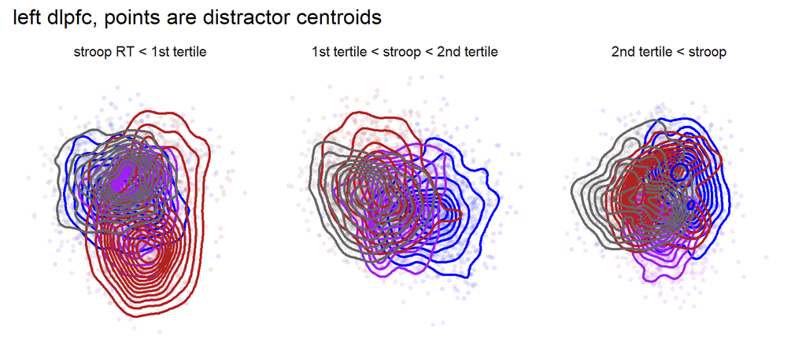

```r
## dlpfc

mrot.boot.dlpfc.l <- l.mrot.boot[[4]]
mrot.boot.dlpfc.l <- do.call(rbind, mrot.boot.dlpfc.l)

mrot.boot.dlpfc.l %>%
   mutate(
    word = tolower(as.character(word)),
    # congruency = as.character(congruency),
    tri = relevel(tri, "top")
  ) %>%
  group_by(iter, word, tri) %>%
  summarize(MDS1 = mean(MDS1), MDS2 = mean(MDS2)) %>%
  ggplot(aes(x = MDS1, y = MDS2, color = word)) +
  geom_point(alpha = 0.1, aes(fill = word), shape = 16) +
  geom_density_2d(size = 1) +
  scale_color_manual(values = c(blue = "blue", white = "grey40", red = "firebrick", purple = "purple")) +
  facet_grid(
    cols = vars(tri),
    labeller = labeller(
      tri = c(top = "stroop RT < 1st tertile", mid = "1st tertile < stroop < 2nd tertile", bot = "2nd tertile < stroop")
    )
  ) +
  theme_minimal(base_size = 14) +
  theme(
    panel.grid = element_blank(),
    axis.text =  element_blank(),
    axis.title = element_blank(),
    legend.position = "none"
  ) +
  labs(title = "left dlpfc, points are distractor centroids")
```